# Лабораторная работа №5

### 2.13 Errorbars

Построим график исходных значений (рис. #fig:032):

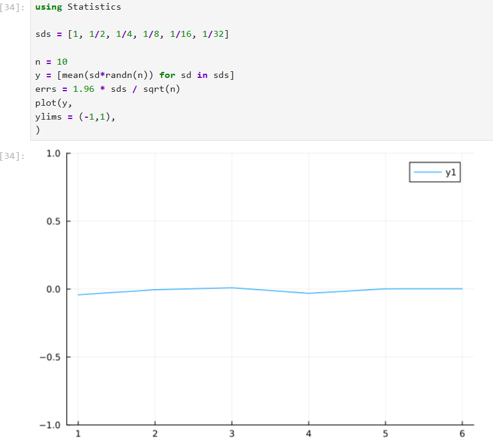

График исходных значений

Построим график отклонений от исходных значений (рис. #fig:033):

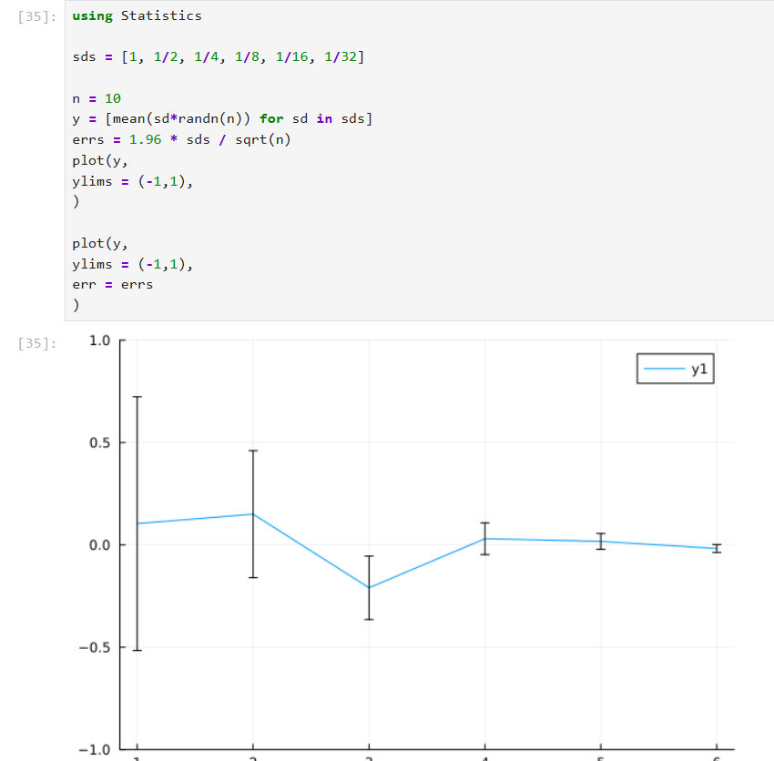

График исходных значений с отклонениями

Повернём график (рис. #fig:034):

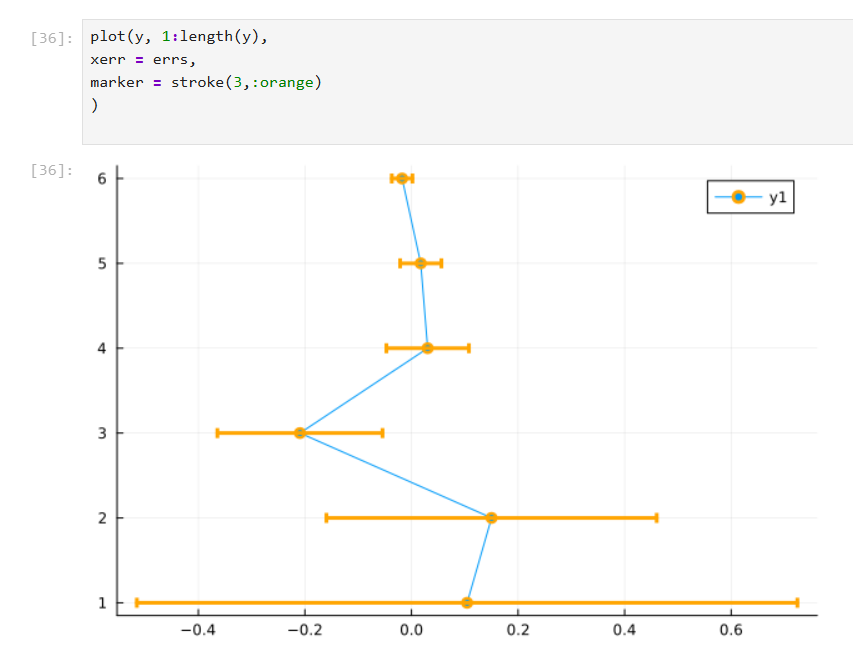

Поворот графика

Заполним область цветом (рис. #fig:035):

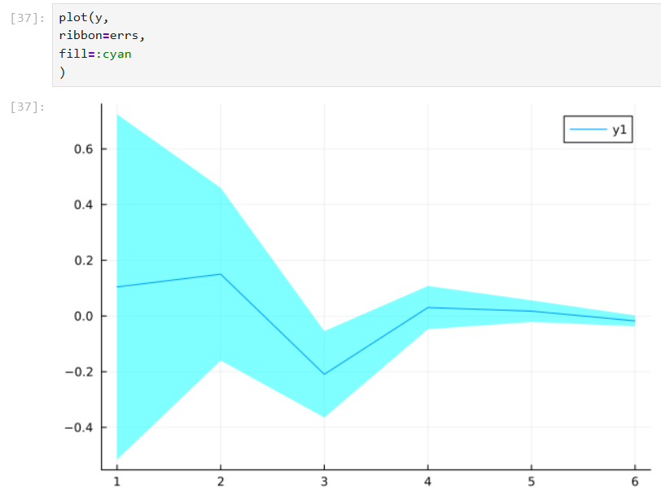

Заполнение цветом

Можно построить график ошибок по двум осям (рис. #fig:036):

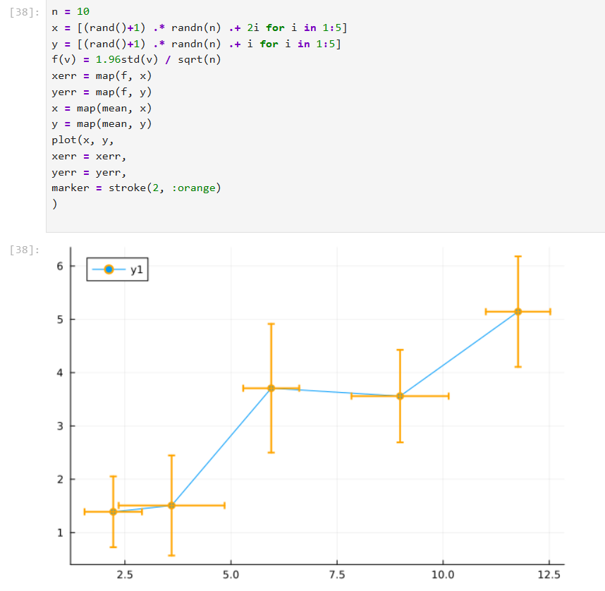

График ошибок по двум осям

Можно построить график асимметричных ошибок по двум осям (рис. #fig:037):

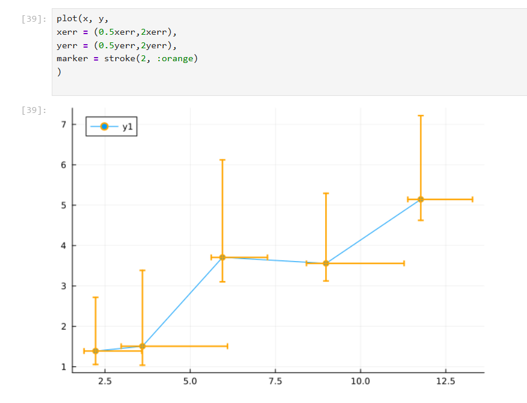

График асимметричных ошибок по двум осям

### 2.14 Использование пакета Distributions

Строим гистограмму (рис. #fig:038):

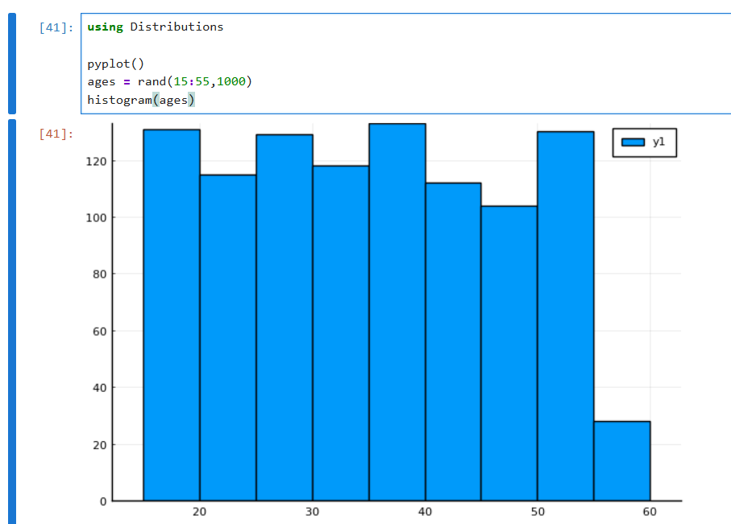

Гистограмма, построенная по массиву случайных чисел

Задаём нормальное распределение и строим гистограмму (рис. #fig:039):

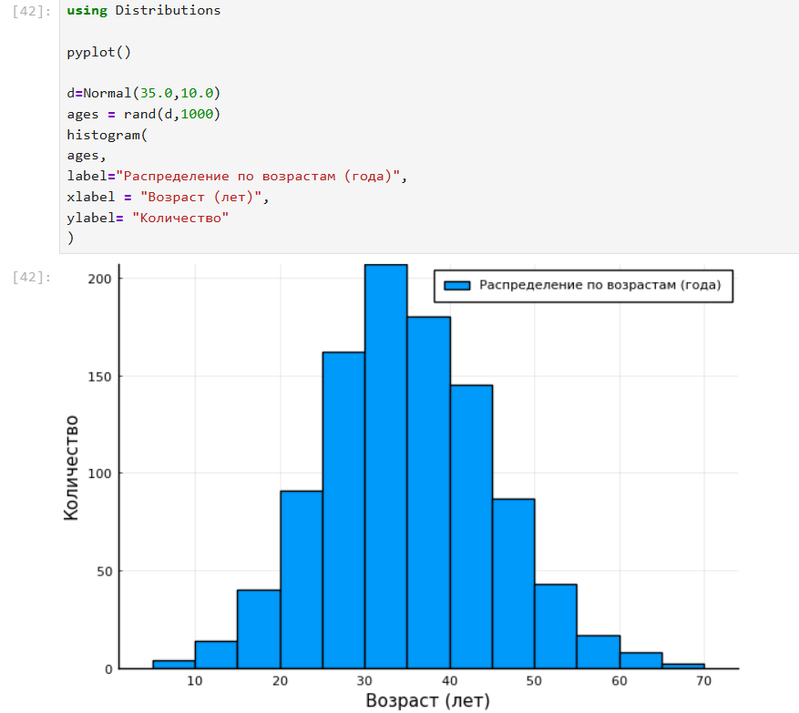

Гистограмма нормального распределения

Далее применим для построения нескольких гистограмм распределения людей по возрастам на одном графике plotly() (рис. #fig:040):

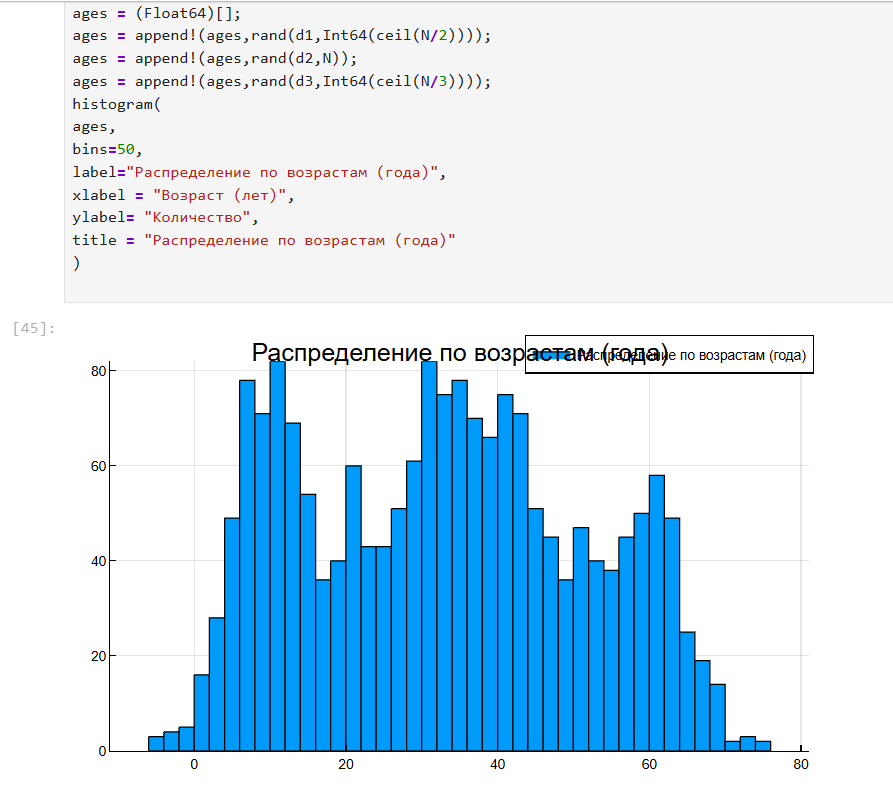

Гистограмма распределения людей по возрастам

### 2.15 Подграфики

Определим макет расположения графиков. Команда layout принимает кортеж layout = (N, M), который строит сетку графиков N×M. Например, если задать layout = (4,1) на графике четыре серии, то получим четыре ряда графиков (рис. #fig:041):

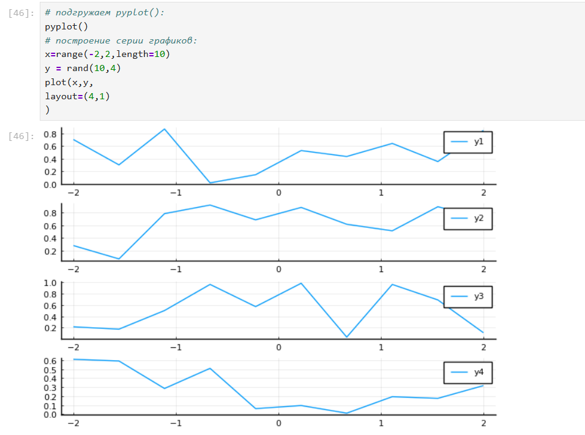

Серия из 4-х графиков в ряд

Для автоматического вычисления сетки необходимо передать layout целое число (рис. #fig:042):

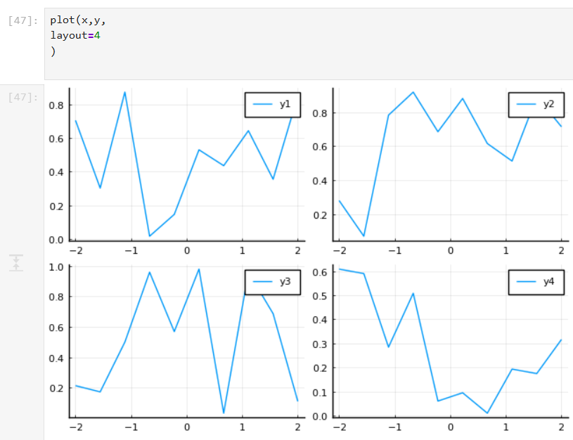

Серия из 4-х графиков в сетке

Можно сгенерировать отдельные графики и объединить их в один, например, в сетке 2 × 2 (рис. #fig:043):

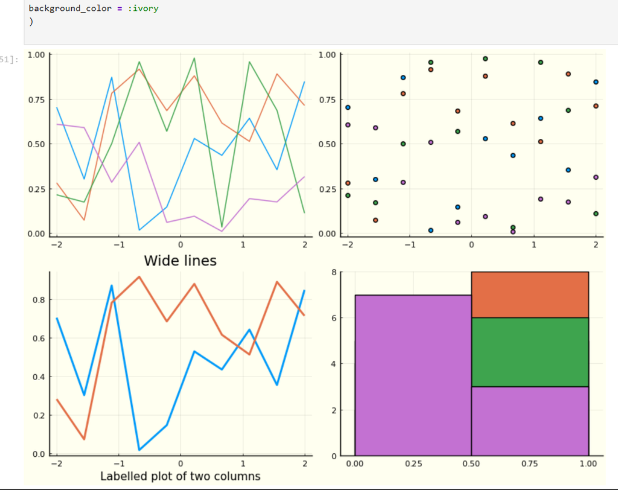

Объединение нескольких графиков в одной сетке

Разнообразные варианты представления данных (рис. #fig:044):

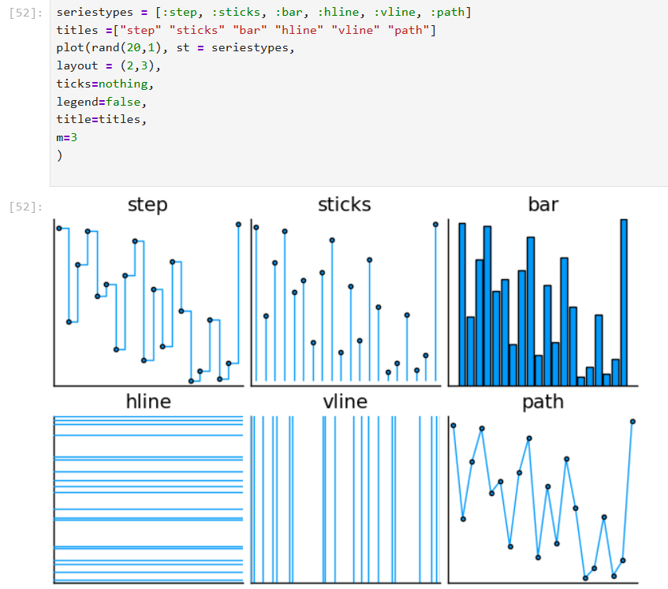

Разнообразные варианты представления данных

Применение макроса @layout — наиболее простой способ определения сложных макетов. Точные размеры могут быть заданы с помощью фигурных скобок, в противном случае пространство будет поровну разделено между графиками (рис. #fig:045):

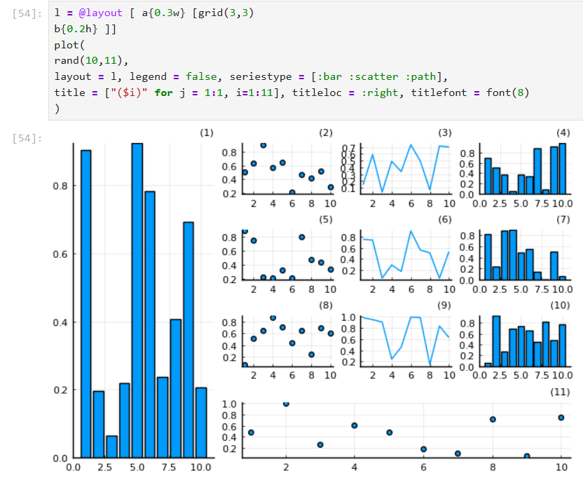

Демонстрация применения сложного макета для построения графиков

### 2.16 Самостоятельное выполнение

**Выполнение задания №1** (рис. #fig:046):

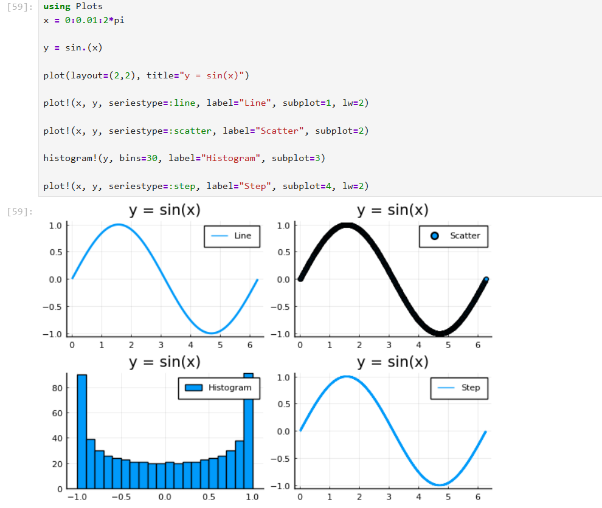

Решение задания №1

**Выполнение задания №2** (рис. #fig:047):

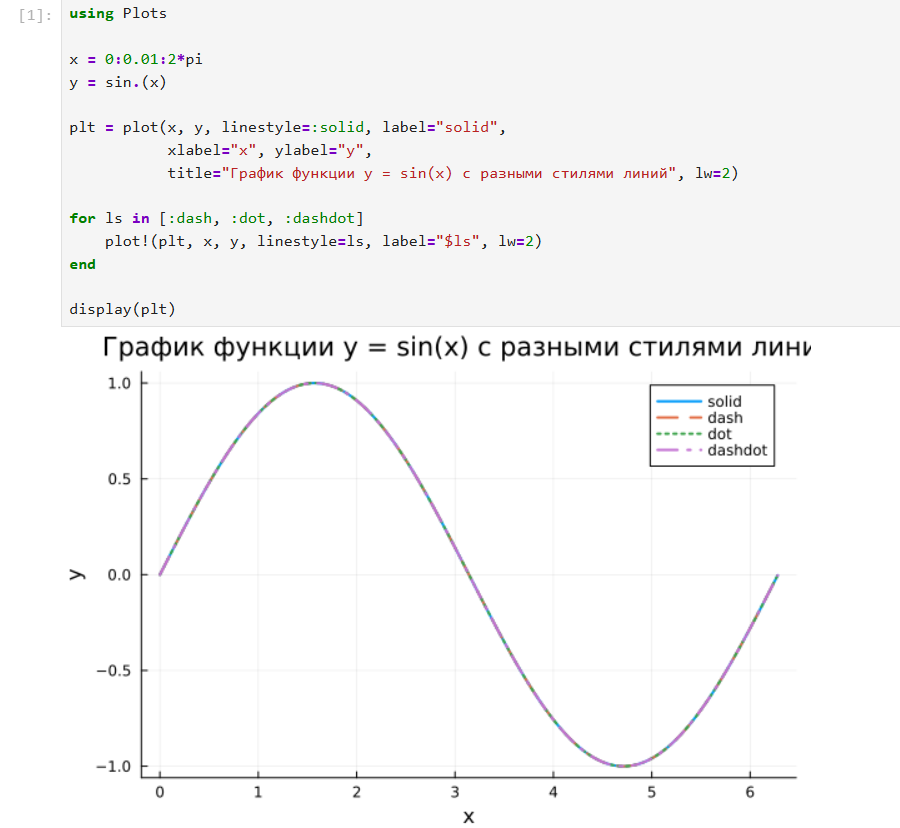

Решение задания №2

**Выполнение задания №3** (рис. #fig:048):

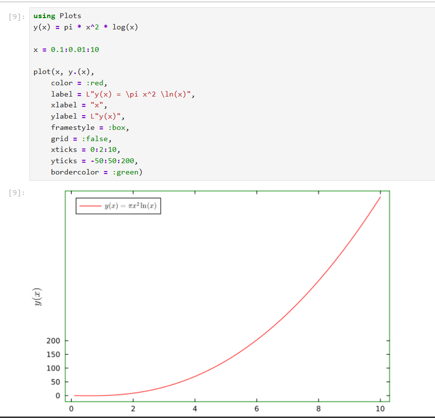

Решение задания №3

**Выполнение задания №4** (рис. #fig:049):

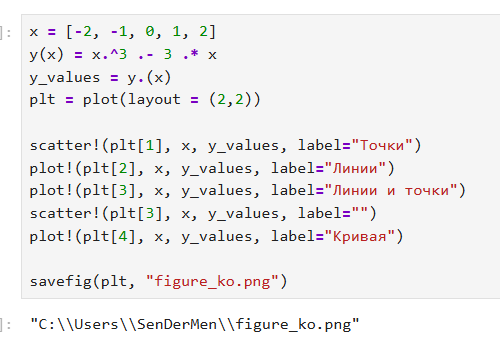

Решение задания №4

**Выполнение задания №5** (рис. #fig:050 – #fig:051):

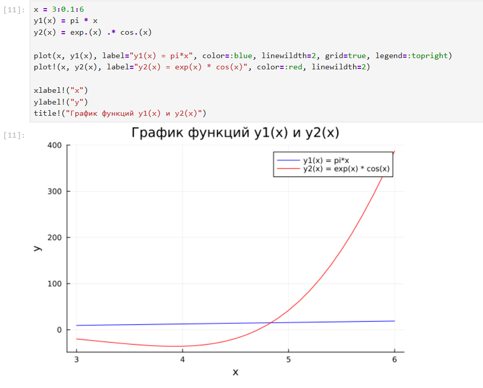

Решение задания №5

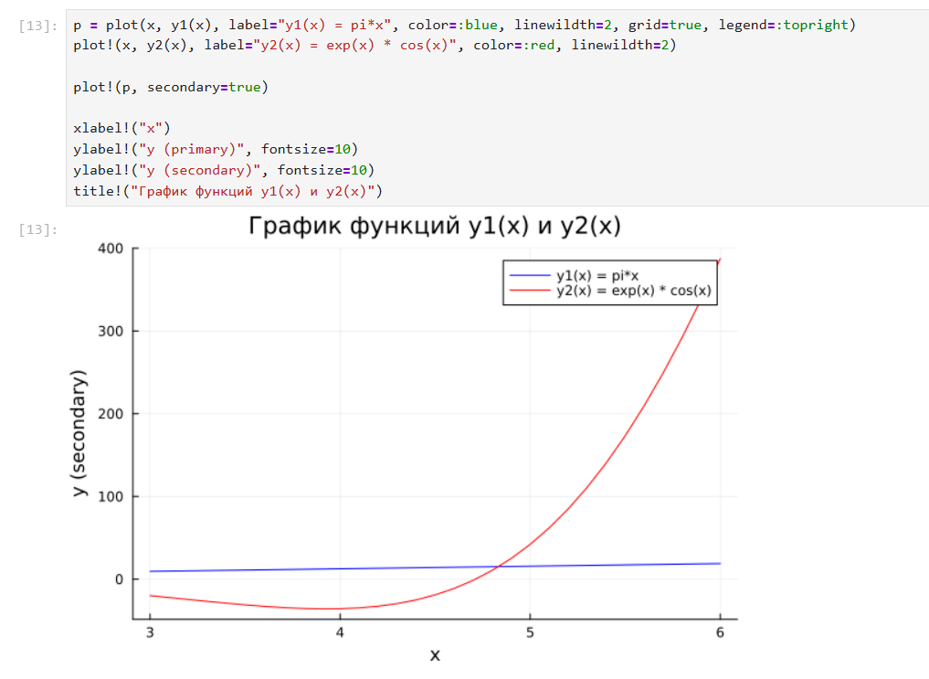

Решение задания №5

**Выполнение задания №6** (рис. #fig:052):

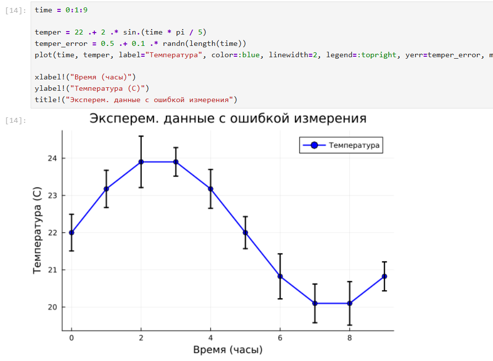

Решение задания №6

**Выполнение задания №7** (рис. #fig:053):

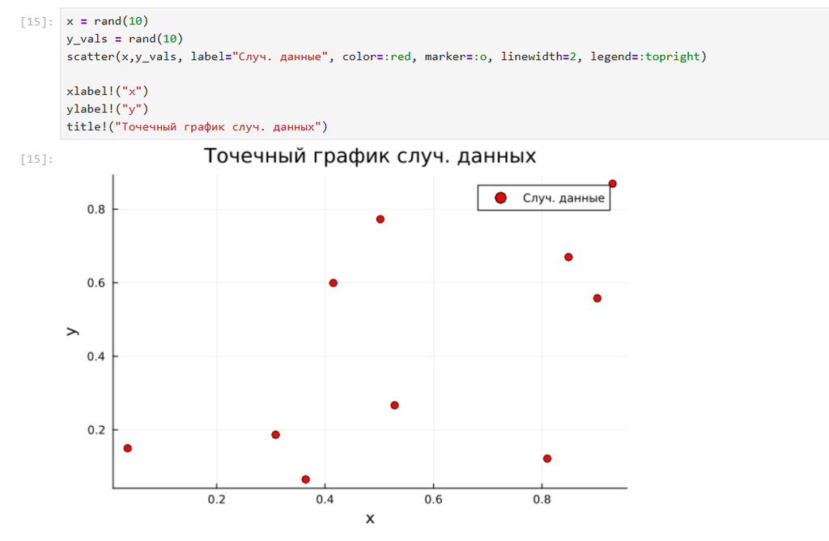

Решение задания №7

**Выполнение задания №8** (рис. #fig:054):

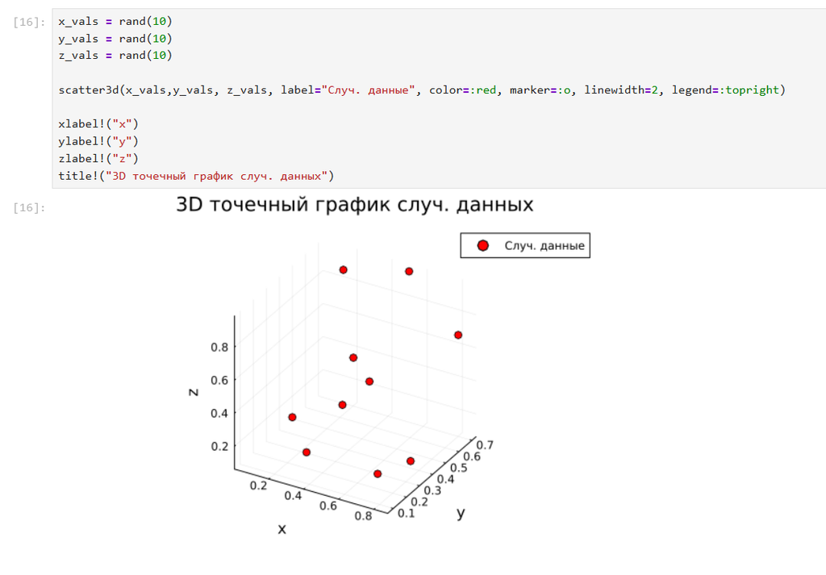

Решение задания №8

**Выполнение задания №9** (рис. #fig:055):

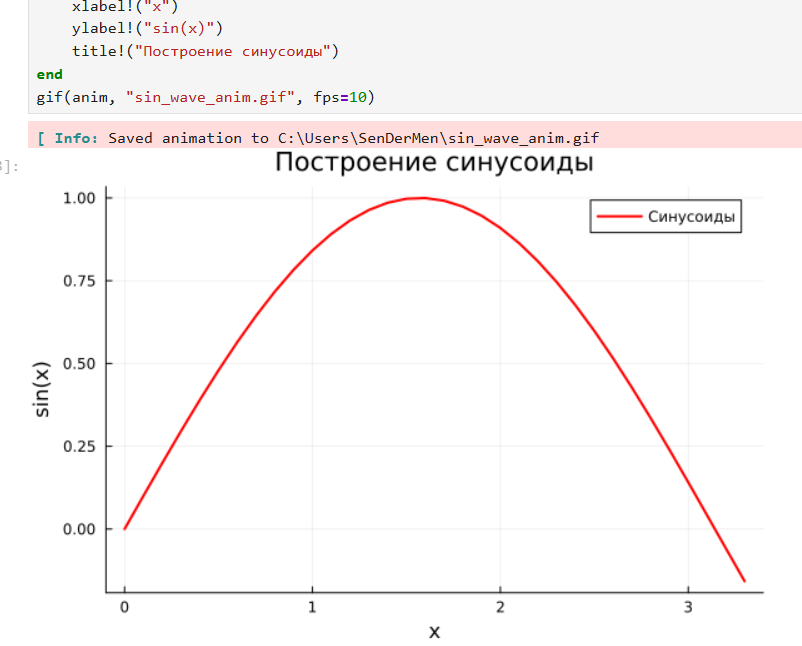

Решение задания №9

**Выполнение задания №10** (рис. #fig:056):

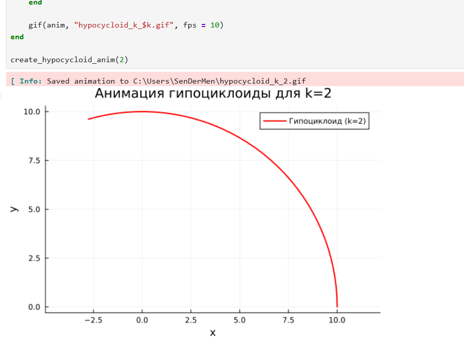

Решение задания №10

**Выполнение задания №11** (рис. #fig:057):

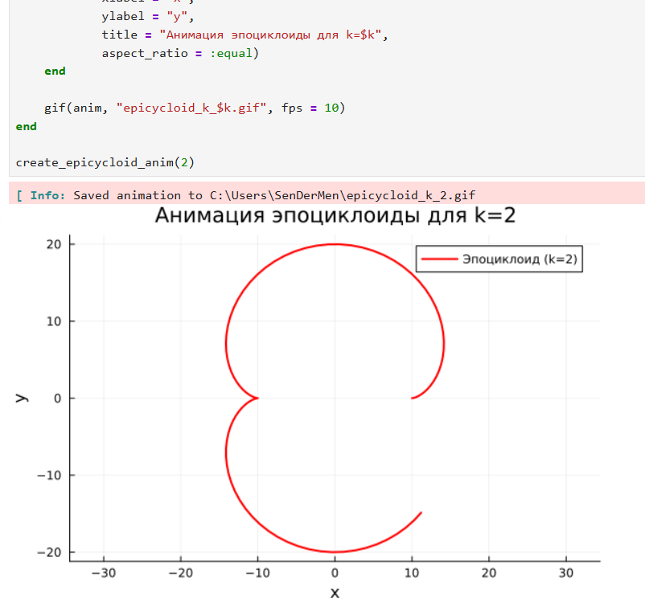

Решение задания №11

## 3. Вывод

В ходе выполнения лабораторной работы был освоен синтаксис языка Julia для построения графиков.